# DCP Examples - Second Order Cone Programming (SOCP)

Biostat/Biomath M257

Author

Dr. Hua Zhou @ UCLA

Published

June 3, 2025

## 1 SOCP

- A **second-order cone program (SOCP)**
  $$\begin{eqnarray*}
  &\text{minimize}& \mathbf{f}^T \mathbf{x} \\
  &\text{subject to}& \|\mathbf{A}_i \mathbf{x} + \mathbf{b}_i\|_2 \le \mathbf{c}_i^T \mathbf{x} + d_i, \quad i = 1,\ldots,m \\
  & & \mathbf{F} \mathbf{x} = \mathbf{g}
  \end{eqnarray*}$$
  over $\mathbf{x} \in \mathbb{R}^n$. This says the points $(\mathbf{A}_i \mathbf{x} + \mathbf{b}_i, \mathbf{c}_i^T \mathbf{x} + d_i)$ live in the second order cone (ice cream cone, Lorentz cone, quadratic cone)
  $$\begin{eqnarray*}
  \mathbf{Q}^{n+1} = \{(\mathbf{x}, t): \|\mathbf{x}\|_2 \le t\}
  \end{eqnarray*}$$
  in $\mathbb{R}^{n+1}$.
- QP is a special case of SOCP. Why?
- When $\mathbf{c}_i = \mathbf{0}$ for $i=1,\ldots,m$, SOCP is equivalent to a **quadratically constrained quadratic program (QCQP)**
  $$\begin{eqnarray*}
  &\text{minimize}& (1/2) \mathbf{x}^T \mathbf{P}_0 \mathbf{x} + \mathbf{q}_0^T \mathbf{x} \\
  &\text{subject to}& (1/2) \mathbf{x}^T \mathbf{P}_i \mathbf{x} + \mathbf{q}_i^T \mathbf{x} + r_i \le 0, \quad i = 1,\ldots,m \\
  & & \mathbf{A} \mathbf{x} = \mathbf{b},
  \end{eqnarray*}$$
  where $\mathbf{P}_i \in \mathbf{S}_+^n$, $i=0,1,\ldots,m$. Why?
- A **rotated quadratic cone** in $\mathbb{R}^{n+2}$ is
  $$\begin{eqnarray*}
  \mathbf{Q}_r^{n+2} = \{(\mathbf{x}, t_1, t_2): \|\mathbf{x}\|_2^2 \le 2 t_1 t_2, t_1 \ge 0, t_2 \ge 0\}.
  \end{eqnarray*}$$
  A point $\mathbf{x} \in \mathbb{R}^{n+1}$ belongs to the second order cone $\mathbf{Q}^{n+1}$ if and only if
  $$\begin{eqnarray*}
  \begin{pmatrix} \mathbf{I}_{n-2} & 0 & 0 \\
  0 & - 1/\sqrt 2 & 1 / \sqrt 2 \\
  0 & 1/\sqrt 2 & 1 / \sqrt 2
  \end{pmatrix} \mathbf{x}
  \end{eqnarray*}$$
  belongs to the rotated quadratic cone $\mathbf{Q}_r^{n+1}$.

  Gurobi allows users to input second order cone constraint and quadratic constraints directly.

  Mosek allows users to input second order cone constraint, quadratic constraints, and rotated quadratic cone constraint directly.
- Following sets are *(rotated) quadratic cone representable sets*:
  - (Absolute values) $|x| \le t \Leftrightarrow (x, t) \in \mathbf{Q}^2$.
  - Euclidean norms) $\|\mathbf{x}\|_2 \le t \Leftrightarrow (\mathbf{x}, t) \in \mathbf{Q}^{n+1}$.
  - (Sume of squares) $\|\mathbf{x}\|_2^2 \le t \Leftrightarrow (\mathbf{x}, t, 1/2) \in \mathbf{Q}_r^{n+2}$.
  - (Ellipsoid) For $\mathbf{P} \in \mathbf{S}_+^n$ and if $\mathbf{P} = \mathbf{F}^T \mathbf{F}$, where $\mathbf{F} \in \mathbf{R}^{n \times k}$, then
    $$\begin{eqnarray*}
    & & (1/2) \mathbf{x}^T \mathbf{P} \mathbf{x} + \mathbf{c}^T \mathbf{x} + r \le 0 \\
    &\Leftrightarrow& \mathbf{x}^T \mathbf{P} \mathbf{x} \le 2t, t + \mathbf{c}^T \mathbf{x} + r = 0 \\
    &\Leftrightarrow& (\mathbf{F} \mathbf{x}, t, 1) \in \mathbf{Q}_r^{k+2}, t + \mathbf{c}^T \mathbf{x} + r = 0.
    \end{eqnarray*}$$
    Similarly,
    $$\begin{eqnarray*}
    \|\mathbf{F} (\mathbf{x} - \mathbf{c})\|_2 \le t \Leftrightarrow (\mathbf{y}, t) \in \mathbf{Q}^{n+1}, \mathbf{y} = \mathbf{F}(\mathbf{x} - \mathbf{c}).
    \end{eqnarray*}$$
    This fact shows that QP and QCQP are instances of SOCP.
  - (Second order cones) $\|\mathbf{A} \mathbf{x} + \mathbf{b}\|_2 \le \mathbf{c}^T \mathbf{x} + d \Leftrightarrow (\mathbf{A} \mathbf{x} + \mathbf{b}, \mathbf{c}^T \mathbf{x} + d) \in \mathbf{Q}^{m+1}$.
  - (Simple polynomial sets)
    $$\begin{eqnarray*}
    \{(t, x): |t| \le \sqrt x, x \ge 0\} &=& \{ (t,x): (t, x, 1/2) \in \mathbf{Q}_r^3\} \\
    \{(t, x): t \ge x^{-1}, x \ge 0\} &=& \{ (t,x): (\sqrt 2, x, t) \in \mathbf{Q}_r^3\} \\
    \{(t, x): t \ge x^{3/2}, x \ge 0\} &=& \{ (t,x): (x, s, t), (s, x, 1/8) \in \mathbf{Q}_r^3\} \\
    \{(t, x): t \ge x^{5/3}, x \ge 0\} &=& \{ (t,x): (x, s, t), (s, 1/8, z), (z, s, x) \in \mathbf{Q}_r^3\} \\
    \{(t, x): t \ge x^{(2k-1)/k}, x \ge 0\}&,& k \ge 2, \text{can be represented similarly} \\
    \{(t, x): t \ge x^{-2}, x \ge 0\} &=& \{ (t,x): (s, t, 1/2), (\sqrt 2, x, s) \in \mathbf{Q}_r^3\} \\
    \{(t, x, y): t \ge |x|^3/y^2, y \ge 0\} &=& \{ (t,x,y): (x, z) \in \mathbf{Q}^2, (z, y/ 2, s), (s, t/2, z) \in \mathbf{Q}_r^3\}
    \end{eqnarray*}$$
  - (Geometric mean) The hypograph of the (concave) geometric mean function
    $$\begin{eqnarray*}
    \mathbf{K}_{\text{gm}}^n = \{(\mathbf{x}, t) \in \mathbb{R}^{n+1}: (x_1 x_2 \cdots x_n)^{1/n} \ge t, \mathbf{x} \succeq \mathbf{0}\}
    \end{eqnarray*}$$
    can be represented by rotated quadratic cones. For example,
    $$\begin{eqnarray*}
    \mathbf{K}_{\text{gm}}^2 &=& \{(x_1, x_2, t): \sqrt{x_1 x_2} \ge t, x_1, x_2 \ge 0\} \\
    &=& \{(x_1, x_2, t): (\sqrt 2 t, x_1, x_2) \in \mathbf{Q}_r^3\}.
    \end{eqnarray*}$$
  - (Harmonic mean) The hypograph of the harmonic mean function $\left( n^{-1} \sum_{i=1}^n x_i^{-1} \right)^{-1}$ can be represented by rotated quadratic cones
    $$\begin{eqnarray*}
    & & \left( n^{-1} \sum_{i=1}^n x_i^{-1} \right)^{-1} \ge t, \mathbf{x} \succeq \mathbf{0} \\
    &\Leftrightarrow& n^{-1} \sum_{i=1}^n x_i^{-1} \le y, \mathbf{x} \succeq \mathbf{0} \\
    &\Leftrightarrow& x_i z_i \ge 1, \sum_{i=1}^n z_i = ny, \mathbf{x} \succeq \mathbf{0} \\
    &\Leftrightarrow& 2 x_i z_i \ge 2, \sum_{i=1}^n z_i = ny, \mathbf{x} \succeq \mathbf{0}, \mathbf{z} \succeq \mathbf{0} \\
    &\Leftrightarrow& (\sqrt 2, x_i, z_i) \in \mathbf{Q}_r^3, \mathbf{0}^T \mathbf{z} = ny, \mathbf{x} \succeq \mathbf{0}, \mathbf{z} \succeq \mathbf{0}.
    \end{eqnarray*}$$
  - (Convex increasing rational powers) For $p,q \in \mathbf{Z}_+$ and $p/q \ge 1$,
    $$\begin{eqnarray*}
    \mathbf{K}^{p/q} = \{(x, t): x^{p/q} \le t, x \ge 0\} = \{(x,t): (t\mathbf{1}_q, \mathbf{1}_{p-q}, x) \in \mathbf{K}_{\text{gm}}^p\}.
    \end{eqnarray*}$$
  - (Convex decreasing rational powers) For any $p,q \in \mathbf{Z}_+$,
    $$\begin{eqnarray*}
    \mathbf{K}^{-p/q} = \{(x, t): x^{-p/q} \le t, x \ge 0\} = \{(x,t): (x\mathbf{1}_p, t\mathbf{1}_{q}, 1) \in \mathbf{K}_{\text{gm}}^{p+q}\}.
    \end{eqnarray*}$$
  - (Power cones) The *power cone* with rational powers is
    $$\begin{eqnarray*}
    \mathbf{K}_{\alpha}^{n+1} = \left\{ (\mathbf{x},y) \in \mathbb{R}_+^n \times \mathbb{R}: |y| \le \prod_{j=1}^n x_j^{p_j/q_j} \right\},
    \end{eqnarray*}$$
    where $p_j, q_j$ are integers satisfying $0 < p_j \le q_j$ and $\sum_{j=1}^n p_j/q_j = 1$. Let $\beta = \text{lcm}(q_1,\ldots, q_n)$ and
    $$\begin{eqnarray*}
    s_j = \beta \sum_{k=1}^j \frac{p_k}{q_k}, \quad j=1,\ldots,n-1.
    \end{eqnarray*}$$
    Then it can be represented as
    $$\begin{eqnarray*}
    & & |y| \le (z_1 z_2 \cdots z_\beta)^{1/q} \\
    & & z_1 = \cdots = z_{s_1} = x_1, \quad z_{s_1+1} = \cdots = z_{s_2} = x_2, \quad z_{s_{n-1}+1} = \cdots = z_\beta = x_n.
    \end{eqnarray*}$$
- References for above examples: Papers Lobo, Vandergerghe, Boyd, Lebret (1998), [Alizadeh and Goldfarb (2003)](https://doi.org/10.1007/s10107-002-0339-5), and book by [Ben-Tal and Nemirovski (2001)](https://doi.org/10.1137/1.9780898718829). Now our catalogue of SOCP terms includes all above terms.
- Most of these function are implemented as the built-in function in the convex optimization modeling language cvx (for Matlab) or Convex.jl (for Julia).

## 2 SOCP example: group lasso

- In many applications, we need to perform variable selection at group level. For instance, in factorial analysis, we want to select or de-select the group of regression coefficients for a factor simultaneously. [Yuan and Lin (2006)](https://doi.org/10.1111/j.1467-9868.2005.00532.x) propose the group lasso that
  $$\begin{eqnarray*}
  &\text{minimize}& \frac 12 \|\mathbf{y} - \beta_0 \mathbf{1} - \mathbf{X} \beta\|_2^2 + \lambda \sum_{g=1}^G w_g \|\beta_g\|_2,
  \end{eqnarray*}$$
  where $\beta_g$ is the subvector of regression coefficients for group $g$, and $w_g$ are fixed group weights. This is equivalent to the SOCP
  $$\begin{eqnarray*}
  &\text{minimize}& \frac 12 \beta^T \mathbf{X}^T \left(\mathbf{I} - \frac{\mathbf{1} \mathbf{1}^T}{n} \right) \mathbf{X} \beta + \\
  & & \quad \mathbf{y}^T \left(\mathbf{I} - \frac{\mathbf{1} \mathbf{1}^T}{n} \right) \mathbf{X} \beta + \lambda \sum_{g=1}^G w_g t_g \\
  &\text{subject to}& \|\beta_g\|_2 \le t_g, \quad g = 1,\ldots, G,
  \end{eqnarray*}$$
  in variables $\beta$ and $t_1,\ldots,t_G$.
- Overlapping groups are allowed here.

## 3 SOCP example: sparse group lasso

- $$\begin{eqnarray*}
  &\text{minimize}& \frac 12 \|\mathbf{y} - \beta_0 \mathbf{1} - \mathbf{X} \beta\|_2^2 + \lambda_1 \|\beta\|_1 + \lambda_2 \sum_{g=1}^G w_g \|\beta_g\|_2
  \end{eqnarray*}$$
  achieves sparsity at both group and individual coefficient level and can be solved by SOCP as well.

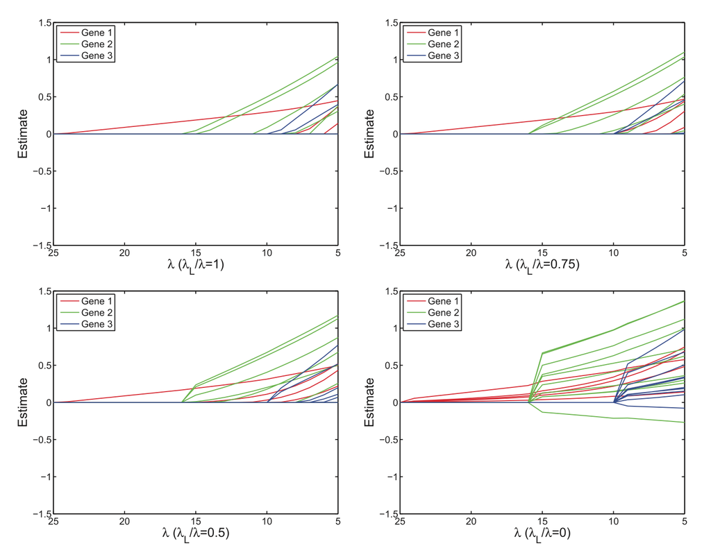

- Apparently we can solve any previous loss functions (quantile, $\ell_1$, composite quantile, Huber, multi-response model) plus group or sparse group penalty by SOCP.

## 4 SOCP example: square-root lasso

- [Belloni, Chernozhukov, and Wang (2011)](https://www.jstor.org/stable/23076172) minimizes
  $$\begin{eqnarray*}
  \|\mathbf{y} - \beta_0 \mathbf{1} - \mathbf{X} \beta\|_2 + \lambda \|\beta\|_1
  \end{eqnarray*}$$
  by SOCP. This variant generates the same solution path as lasso (why?) but simplifies the choice of $\lambda$.
- A demo example: http://hua-zhou.github.io/teaching/biostatm280-2016winter/lasso.html

## 6 SOCP example: $\ell_p$

- $\ell_p$ regression with $p \ge 1$ a rational number
  $$\begin{eqnarray*}
  &\text{minimize}& \|\mathbf{y} - \mathbf{X} \beta\|_p
  \end{eqnarray*}$$
  can be formulated as a SOCP. Why? For instance, $\ell_{3/2}$ regression combines advantage of both robust $\ell_1$ regression and least squares.